# Project 2

Ellen Kim

2020-10-07

```r
library(tidyverse)
library(openintro)
library (readr)
library(dplyr)
```

## Problem 1: Students performance in exams

Question posed by discussion forum: Correlation between students performance and parental level of education.

```r
# read in data
url_1="https://raw.githubusercontent.com/Lnkiim/DATA607FALL202/master/Week6/StudentsPerformance.csv"
raw_studentExam <-read_csv(url(url_1))
```

### What was the average score according to parental level of education?

```r
# change header names
studentExam <-
  raw_studentExam %>%
    rename(reading_score = `reading score`,
           math_score = `math score`,
          writing_score = `writing score`,
          parent_education = `parental level of education`,
          test_prep = `test preparation course`,
          race_group = `race/ethnicity`
          )

# create total score
studentExam <-
  studentExam %>%
    mutate(total_score = writing_score + math_score +reading_score)


# calculate average
avgByParentEd <-
  studentExam %>%
    select(parent_education, total_score, math_score, reading_score, writing_score) %>%
      group_by(parent_education) %>%
        summarize(avg_total_score = mean(total_score),
                  avg_math = mean(math_score),
                  avg_reading = mean(reading_score),
                  avg_writing = mean(writing_score)
                  )
```

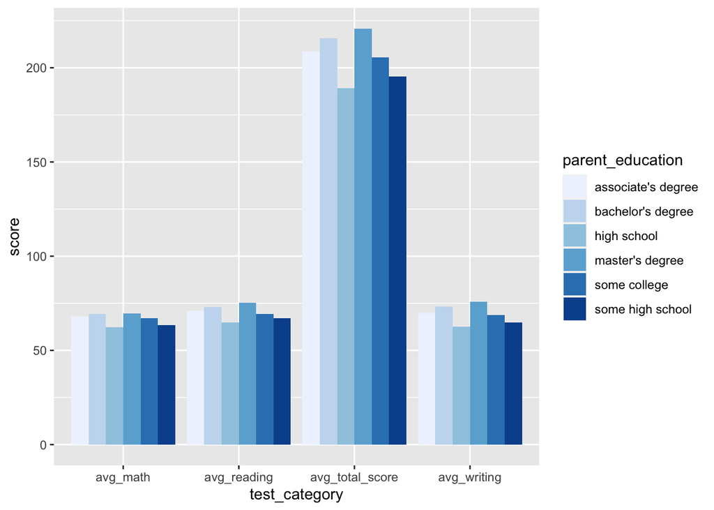

```r
# transpose dataframe to prep for plotting
avgByParentEd <-
  avgByParentEd %>%
    gather(key=test_category, value=score, "avg_total_score":"avg_writing")


# graph

ggplot(data = avgByParentEd, aes(x=test_category, y = score, fill=parent_education)) +
  geom_bar(stat = "identity", position=position_dodge()) +
    scale_fill_brewer(palette="Blues")
```

Question posed by discussion forum: Compare the (Happiness) Score and GDP per capita for the Top 20 countries to observe the correlation (if there is any).

There is a positive correlation between GDP per capita and happiness score.

```r
# Read in data
url_2="https://raw.githubusercontent.com/Lnkiim/DATA607FALL202/master/Week6/happiness2019.csv"
raw_happy <-read_csv(url(url_2))
```

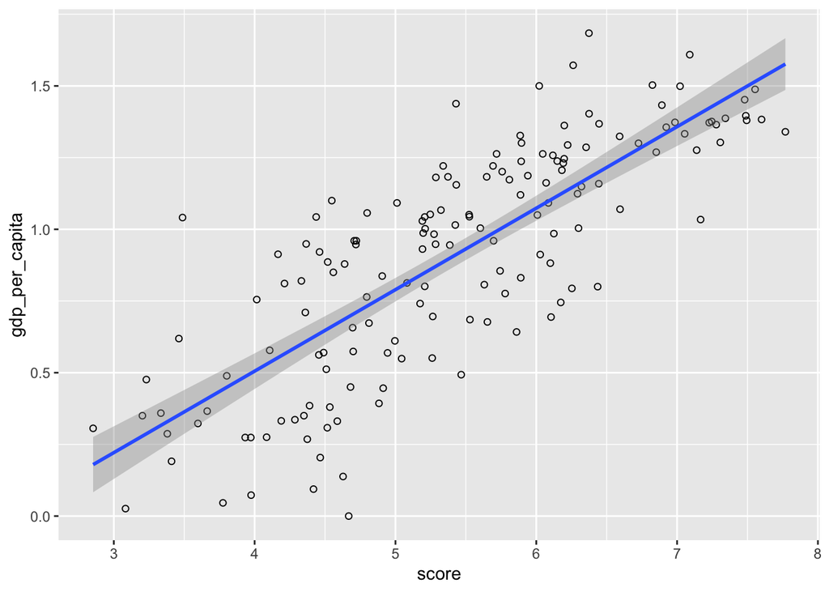

```r
#rename columns
happy1 <- raw_happy
names(happy1) <- c('overall_rank', 'country_region','score','gdp_per_capita', 'social_support', 'health_life_expectancy', 'freedom_choice', 'generosity', 'corruption_perception')

# plot
ggplot(happy1, aes(x=score, y=gdp_per_capita)) +
    geom_point(shape=1) +
       geom_smooth(method=lm)
```

## Problem 3: Food and Agriculture Organization: Who eats the food we grow?

Question posed by discussion forum: “I think the most interesting thing to do would be to figure out if feed has overtaken food in any areas or food items.”

It appears that Denmark and Poland are producing more feed than food.

```r
# Read in the data
url_3="https://raw.githubusercontent.com/Lnkiim/DATA607FALL202/master/Week6/FAO.csv"
raw_food <-read_csv(url(url_3))
food1 <- raw_food

# new attributes
food1$total_production <- rowSums(food1[11:63])
food1$total_last10years <- rowSums(food1[53:63])

# group by country, transpose to element category - feed vs food
feed_country <-
  food1 %>%
      group_by(Element, Area) %>%
        summarize(totalProdByElement = sum(total_production)) %>%
          spread(key = Element, value = totalProdByElement) %>%
            filter(Feed > Food)
print(feed_country)
```

```
## # A tibble: 2 x 3
##   Area       Feed    Food
##   <chr>     <dbl>   <dbl>
## 1 Denmark  861635  502707
## 2 Poland  3729107 3565152
```

## Problem 4: School Diversity

Question posed by discussion forum:“Calculate the racial average for each school in each state and put into a separate table”

Below I’ve changed the percentage column to be expressed as a decimal to avoid confusion on what unit the column is in. The datafram titled `by_school` answer the question posed in the discussion forum.

```r
# Read in the Data
url_4="https://raw.githubusercontent.com/szx868/data607/master/school_diversity.csv"
raw_school <-read_csv(url(url_4))
# percentage should be expressed as decimal to avoid confusion about what unit this column is in
# create new column as percentage
school1 <-
  raw_school %>%
    mutate(Asian = Asian / 100,
           Black = Black / 100,
           Hispanic = Hispanic/100,
           White = White /100,
           Multi = Multi/100
          )


by_school <-
  school1 %>%
    group_by(LEA_NAME) %>%
      summarize(avg_asian = mean(Asian),
                  avg_black = mean(Black),
                  avg_hispanic = mean(Hispanic),
                  avg_white  = mean(White),
                  avg_multi = mean(Multi)
                    )
```

### A Different Question

It doesn’t make much sense to calculate the average when each school has observations from two different date ranges that are decades apart. Especially because we’re investigating something to dynamic and disputed like racial difference in america, it doesn’t make sense to discount the effect of time. It is also difficult to make some conclusion when the data is rolled up to a school level. I’ve decided to investigate how racial percentages play out according to state.

We should look at each date range separately then roll aggregate metrics to a state level.

```r
# split dataframe according to date range

school_1994_1995 <-
 school1 %>%
    filter(SCHOOL_YEAR ==   '1994-1995')

school_2016_2017 <-
 school1 %>%
    filter(SCHOOL_YEAR ==   '2016-2017')

byState_2016 <-
  school_2016_2017 %>%
    group_by(ST) %>%
      summarize(avg_asian = mean(Asian),
                avg_black = mean(Black),
                avg_hispanic = mean(Hispanic),
                avg_white  = mean(White),
                avg_multi = mean(Multi)
                  )
byState_2016$year <- '2016_2017'

byState_1994 <-
  school_1994_1995 %>%
    group_by(ST) %>%
      summarize(avg_asian = mean(Asian),
                avg_black = mean(Black),
                avg_hispanic = mean(Hispanic),
                avg_white  = mean(White),
                avg_multi = mean(Multi)
                  )
byState_1994$year <- '1994_1995'
```

### Graph the changes between the two decades

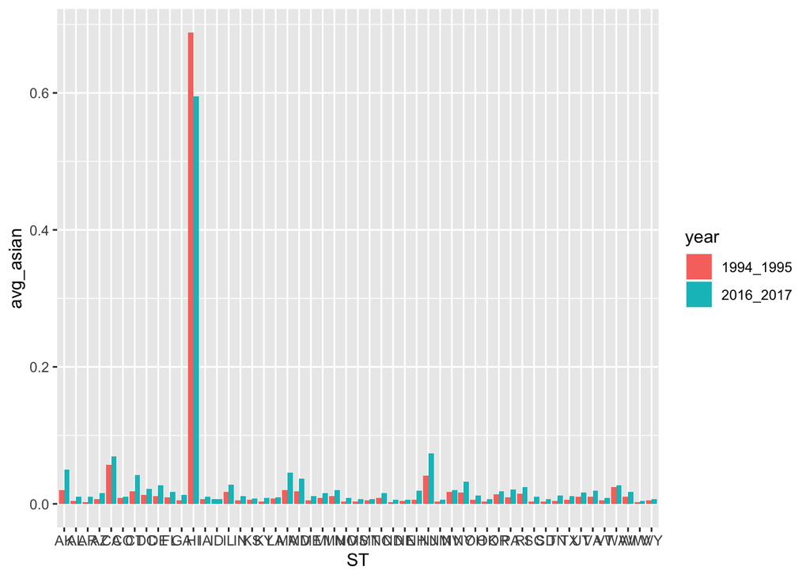

```r
by_state_all <- rbind(byState_1994, byState_2016)

#asian average
  ggplot(by_state_all, aes(x= ST, y= avg_asian, fill=year)) +
      geom_bar(stat='identity',  position=position_dodge())
```

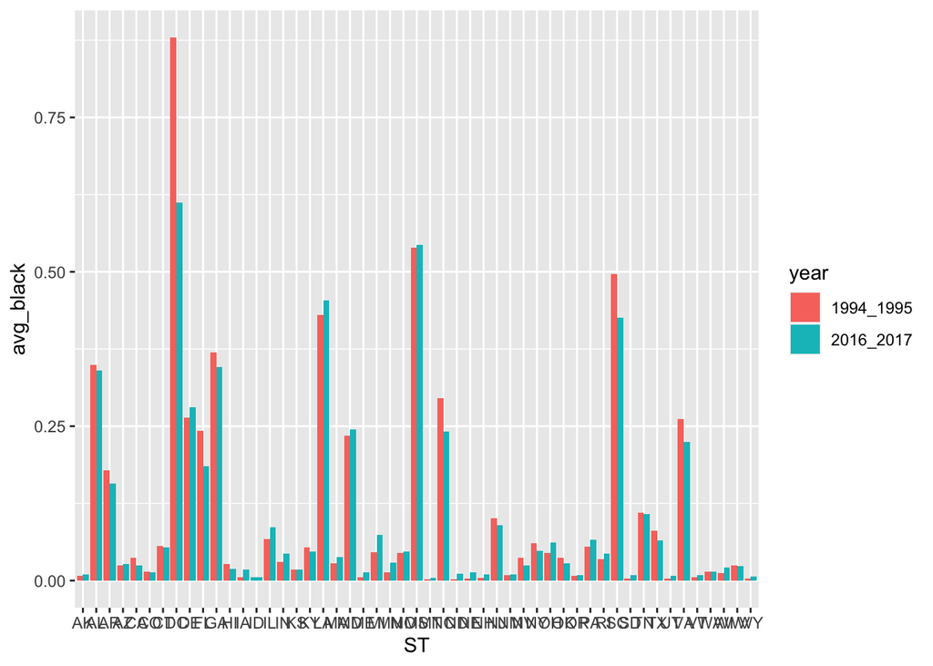

```r
#black average
  ggplot(by_state_all, aes(x= ST, y= avg_black, fill=year)) +
      geom_bar(stat='identity',  position=position_dodge())
```

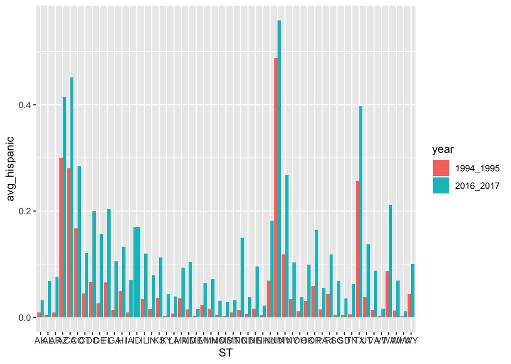

```r
# hispanic average
  ggplot(by_state_all, aes(x= ST, y= avg_hispanic, fill=year)) +
      geom_bar(stat='identity',  position=position_dodge())
```

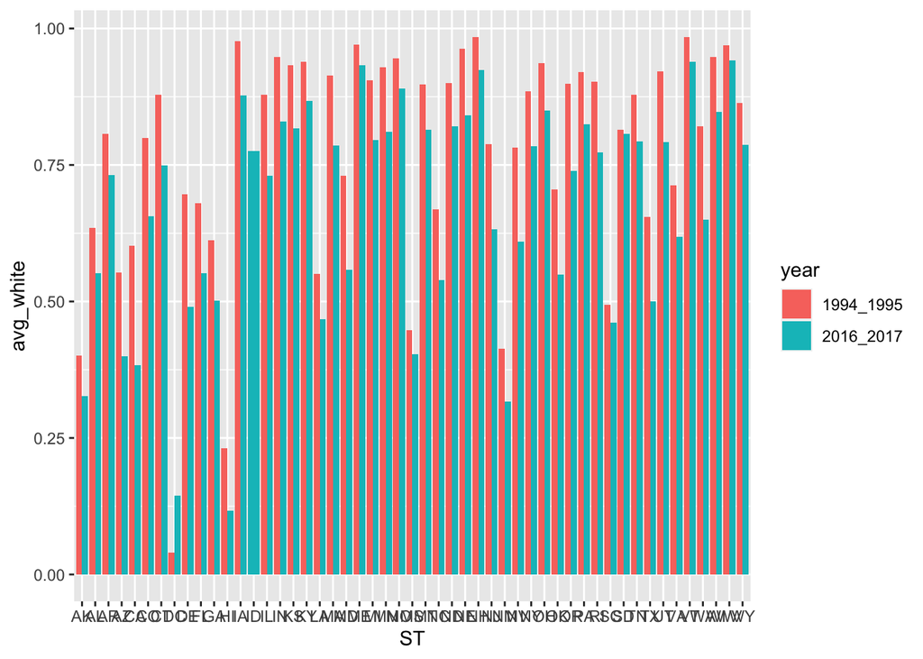

```r
# white average
  ggplot(by_state_all, aes(x= ST, y= avg_white , fill=year)) +
      geom_bar(stat='identity',  position=position_dodge())
```

```r
#multi data doesn't exist for 1994_1995 dataset
```